# Simulations for Animal Breeding Course

Simulating Phenotypic Data

Pablo Dominguez Castano

# 1. Simulating phenotypes

Before building a biological model, we can start by simply generating random numbers.

In R, the function `rnorm()` generates random observations from a normal distribution.

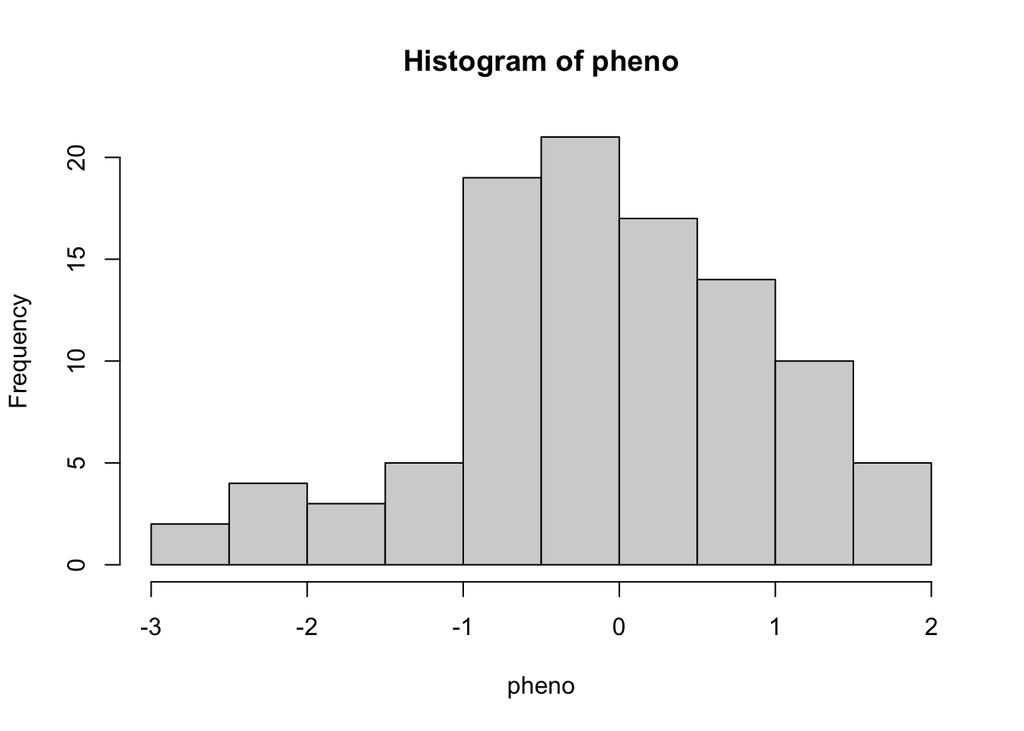

```r
# Clean the R environment
rm(list = ls())

# Set seed to make the simulation reproducible
set.seed(2011)

# Generate 100 random observations
pheno <- rnorm(100)

# Visualize the distribution
hist(pheno)
```

## Think about it

What have we simulated?

The function generated 100 random observations from a standard normal distribution.

However, these values do not yet have a clear biological interpretation.

For example:

- Are they milk yield records?
- Are they body weights?
- Are they average daily gains?

At this point, we cannot tell.

> Generating random numbers is not the same as simulating a biologically meaningful phenotype.

To give biological meaning to the simulation, we need information describing the population that we want to represent.

# 2. Simulating a biologically meaningful phenotype

For this example, we will simulate **daily milk yield (DMY)** of first-parity Holstein cows.

The population parameters are based on:

**Dominguez-Castano et al. (2026), Journal of Dairy Science.**

We assume:

- Mean daily milk yield = 31.8 kg
- Standard deviation = 7.12 kg

These values describe the location and variability of the phenotype in the population.

```r
# Population mean
m_p <- 31.8

# Population standard deviation
sd_p <- 7.12
```

Now we define the number of animals that we want to simulate.

```r
# Number of animals
n <- 1000
```

We can now generate 1,000 phenotypic observations.

```r
# Simulate daily milk yield
dmy <- rnorm(
  n = n,
  mean = m_p,
  sd = sd_p
)
```

Let’s visualize the simulated phenotype.

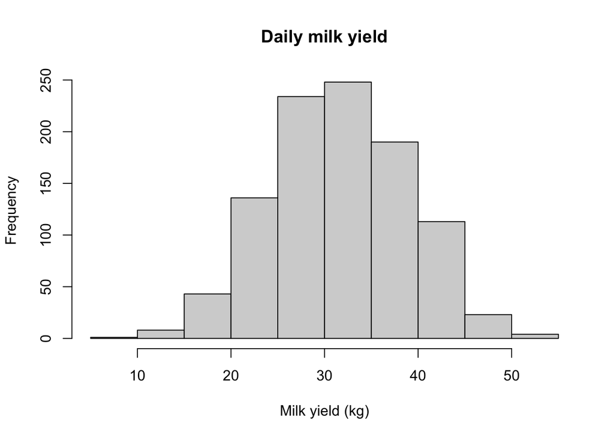

```r
hist(
  dmy,
  main = "Daily milk yield",
  xlab = "Milk yield (kg)"
)
```

Descriptive statistics for the simulated population.

```r
summary(dmy)
```

```
##    Min. 1st Qu.  Median    Mean 3rd Qu.    Max.
##   6.913  26.523  31.570  31.690  36.989  53.826
```

```r
mean(dmy)
```

```
## [1] 31.69043
```

```r
sd(dmy)
```

```
## [1] 7.326433
```

## Think about it

We used:

```r
mean = 31.8
sd   = 7.12
```

but the observed mean and standard deviation of our simulated sample will probably not be exactly these values.

Why?

Because we generated a finite sample from a theoretical population.

Therefore:

**Population parameter ≠ Sample statistic**

With larger simulated populations, the sample statistics will generally become closer to the parameters used to generate the data.

# 3. Organizing the simulated data

Until now, we only have a vector containing milk yield observations.

In real animal datasets, each phenotype belongs to an individual.

Therefore, we first create an animal identification variable and organize the information in a `data.frame`.

```r
dat_dmy <- data.frame(
  animal = 1:n,
  dmy = dmy
)

head(dat_dmy)
```

```
##   animal      dmy
## 1      1 33.85722
## 2      2 36.39082
## 3      3 29.64917
## 4      4 41.43008
## 5      5 31.10076
## 6      6 41.02713
```

Alternatively, we could have generated the phenotypes directly when creating the `data.frame`.

```r
dat_dmy_example <- data.frame(
  animal = 1:n,
  dmy = rnorm(
    n,
    mean = m_p,
    sd = sd_p
  )
)

head(dat_dmy_example)
```

```
##   animal      dmy
## 1      1 40.65620
## 2      2 16.56101
## 3      3 25.46257
## 4      4 26.26377
## 5      5 30.62007
## 6      6 39.70690
```

```r
# Remove this example dataset
rm(dat_dmy_example)
```

From now on, we will continue working with `dat_dmy`.

# 4. Including systematic effects

Animals raised under real production conditions do not all experience exactly the same environment.

Phenotypic differences may be partially explained by systematic factors such as:

- farm;
- season of calving;
- age at calving;
- year;
- parity;
- management conditions.

We will progressively include some of these effects in our simulation.

The general idea is:

$$Phenotype = Population\ mean + Systematic\ effects + Other\ variation$$

At this stage, we will focus only on the **expected phenotype** associated with known systematic effects.

# 5. Systematic effect 1: Farm

Suppose our cows are distributed across three farms:

- Farm A
- Farm B
- Farm C

We can randomly assign each animal to a farm.

```r
dat_dmy$farm <- sample(
  c("A", "B", "C"),
  size = n,
  replace = TRUE
)

head(dat_dmy)
```

```
##   animal      dmy farm
## 1      1 33.85722    C
## 2      2 36.39082    A
## 3      3 29.64917    B
## 4      4 41.43008    C
## 5      5 31.10076    C
## 6      6 41.02713    A
```

We can check how many animals were assigned to each farm.

```r
table(dat_dmy$farm)
```

```
##
##   A   B   C
## 367 298 335
```

With this code, each farm has approximately the same probability of receiving an animal.

However, real datasets are often unbalanced.

For example, suppose:

- 50% of the animals come from Farm A;
- 20% from Farm B;
- 30% from Farm C.

```r
dat_dmy$farm <- sample(
  c("A", "B", "C"),
  size = n,
  replace = TRUE,
  prob = c(0.50, 0.20, 0.30)
)

table(dat_dmy$farm)
```

```
##
##   A   B   C
## 490 213 297
```

## Think about it

Why might real animal datasets be unbalanced?

Possible reasons include:

- different farm sizes;
- different recording intensity;
- different numbers of animals per herd;
- missing records;
- different participation periods.

# 6. Assigning a farm effect

Simply assigning animals to farms does not yet change their expected milk yield.

We now need to define the biological effect associated with each farm.

Suppose:

| Farm | Effect on DMY |
| --- | --- |
| A | +5.0 kg |
| B | 0.0 kg |
| C | +3.5 kg |

We define these effects in R:

```r
farm_effect <- c(
  A = 5,
  B = 0,
  C = 3.5
)
```

Now we assign the corresponding effect to each cow.

```r
dat_dmy$farm_effect <- farm_effect[dat_dmy$farm]

head(dat_dmy)
```

```
##   animal      dmy farm farm_effect
## 1      1 33.85722    A         5.0
## 2      2 36.39082    C         3.5
## 3      3 29.64917    A         5.0
## 4      4 41.43008    A         5.0
## 5      5 31.10076    A         5.0
## 6      6 41.02713    C         3.5
```

For example:

- a cow in Farm A receives `+5 kg`;
- a cow in Farm B receives `0 kg`;
- a cow in Farm C receives `+3.5 kg`.

The farm effect is therefore a **systematic environmental effect**.

# 7. Systematic effect 2: Calving season

Production can also differ depending on the season in which the cow calves.

We will consider four seasons:

- winter;
- spring;
- summer;
- fall.

The probability of calving is not necessarily the same across seasons.

```r
dat_dmy$calv_season <- sample(
  c("winter", "spring", "summer", "fall"),
  size = n,
  replace = TRUE,
  prob = c(0.20, 0.25, 0.25, 0.30)
)
```

Now we define hypothetical effects associated with each calving season.

```r
calvSeason_effect <- c(
  winter = 0,
  spring = 2,
  summer = -3,
  fall = 5
)
```

These values imply that, relative to winter:

- spring increases expected DMY by 2 kg;
- summer decreases expected DMY by 3 kg;
- fall increases expected DMY by 5 kg.

Assign the effect to every cow:

```r
dat_dmy$season_effect <-
  calvSeason_effect[dat_dmy$calv_season]

head(dat_dmy)
```

```
##   animal      dmy farm farm_effect calv_season season_effect
## 1      1 33.85722    A         5.0        fall             5
## 2      2 36.39082    C         3.5      winter             0
## 3      3 29.64917    A         5.0        fall             5
## 4      4 41.43008    A         5.0      spring             2
## 5      5 31.10076    A         5.0      summer            -3
## 6      6 41.02713    C         3.5        fall             5
```

## Think about it

Why could season affect milk production?

Possible explanations include:

- temperature;
- feed availability;
- housing conditions;
- management practices.

The important point is that **season is not a random number added independently to every cow**.

All cows belonging to the same season receive the same systematic effect in our simulation.

# 8. Systematic effect 3: Age at calving

Until now, both farm and calving season were **categorical variables**.

Age is different.

Age is a **continuous variable**.

Suppose first-parity Holstein cows calve between approximately:

$$22 \text{ and } 34 \text{ months}$$

We will express age in years.

```r
dat_dmy$age <- runif(
  n,
  min = 22 / 12,
  max = 34 / 12
)
```

Round age to one decimal place:

```r
dat_dmy$age <- round(dat_dmy$age, 1)
```

Explore the simulated ages.

```r
summary(dat_dmy$age)
```

```
##    Min. 1st Qu.  Median    Mean 3rd Qu.    Max.
##   1.800   2.100   2.400   2.345   2.600   2.800
```

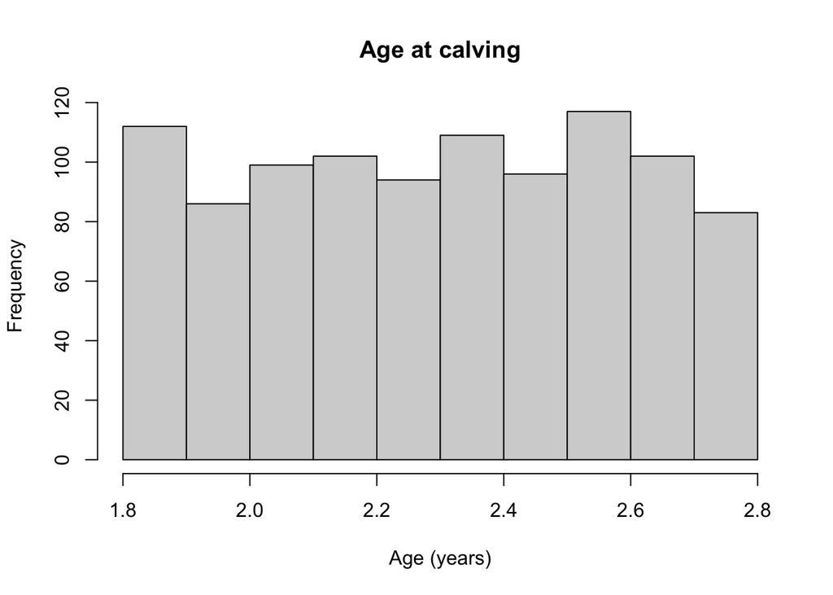

```r
hist(
  dat_dmy$age,
  main = "Age at calving",
  xlab = "Age (years)"
)
```

# 9. Defining the effect of age

For a continuous variable, we can describe its effect using a regression coefficient.

Suppose:

```r
beta_age <- 2.5
```

This means that the expected daily milk yield increases by:

$$2.5 \text{ kg}$$

for every additional year of age at calving.

We calculate the age contribution for each animal:

```r
dat_dmy$age_effect <-
  beta_age * dat_dmy$age

summary(dat_dmy$age_effect)
```

```
##    Min. 1st Qu.  Median    Mean 3rd Qu.    Max.
##   4.500   5.250   6.000   5.863   6.500   7.000
```

## Important

Unlike farm and season, age does not belong to a set of discrete categories.

Its effect changes continuously:

$$Age\ effect = \beta_{age} \times Age$$

# 10. Constructing the expected phenotype

We now have several components that contribute to the expected daily milk yield:

- population mean;
- farm effect;
- calving season effect;
- age effect.

Our model is:

$$DMY_i =
\mu +
Farm_i +
Season_i +
\beta_{age}Age_i$$

We can construct this phenotype directly in R.

```r
dat_dmy$dmy_exp <-
  m_p +
  dat_dmy$farm_effect +
  dat_dmy$season_effect +
  dat_dmy$age_effect
```

Inspect the resulting dataset:

```r
head(dat_dmy)
```

```
##   animal      dmy farm farm_effect calv_season season_effect age age_effect
## 1      1 33.85722    A         5.0        fall             5 2.5       6.25
## 2      2 36.39082    C         3.5      winter             0 2.4       6.00
## 3      3 29.64917    A         5.0        fall             5 2.3       5.75
## 4      4 41.43008    A         5.0      spring             2 2.3       5.75
## 5      5 31.10076    A         5.0      summer            -3 2.5       6.25
## 6      6 41.02713    C         3.5        fall             5 2.4       6.00
##   dmy_exp
## 1   48.05
## 2   41.30
## 3   47.55
## 4   44.55
## 5   40.05
## 6   46.30
```

And visualize the expected DMY:

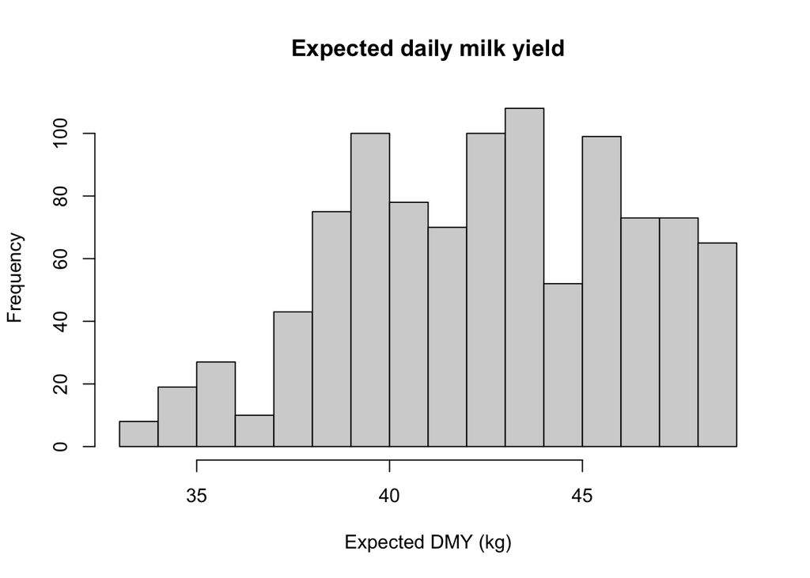

```r
hist(
  dat_dmy$dmy_exp,
  main = "Expected daily milk yield",
  xlab = "Expected DMY (kg)"
)
```

## Important conceptual distinction

`dmy_exp` is the **expected phenotype given the systematic effects included in our model**.

It is not yet a fully realistic observed phenotype.

At this stage, cows with exactly the same:

- farm;
- calving season;
- age

will have the same expected DMY.

Later, we will introduce additional sources of variation.

# 11. Are the simulated systematic effects visible?

Because we generated the data ourselves, we know exactly which effects were included.

We can now inspect whether those effects are visible in the simulated phenotypes.

## Farm means

```r
aggregate(
  dmy_exp ~ farm,
  data = dat_dmy,
  FUN = mean
)
```

```
##   farm  dmy_exp
## 1    A 43.92806
## 2    B 38.87629
## 3    C 42.73519
```

Question:

> Do farms with larger simulated effects show larger average expected milk yield?

## Calving-season means

```r
aggregate(
  dmy_exp ~ calv_season,
  data = dat_dmy,
  FUN = mean
)
```

```
##   calv_season  dmy_exp
## 1        fall 46.22056
## 2      spring 43.08970
## 3      summer 38.19256
## 4      winter 41.07083
```

Question:

> Can we see the negative effect assigned to summer?

## Age

```r
aggregate(
  dmy_exp ~ age,
  data = dat_dmy,
  FUN = mean
)
```

```
##    age  dmy_exp
## 1  1.8 43.14375
## 2  1.9 41.15417
## 3  2.0 42.23605
## 4  2.1 41.65101
## 5  2.2 41.78039
## 6  2.3 42.35851
## 7  2.4 42.39174
## 8  2.5 43.54479
## 9  2.6 42.67607
## 10 2.7 43.13333
## 11 2.8 44.14337
```

Because age is continuous, a scatter plot may also be more informative.

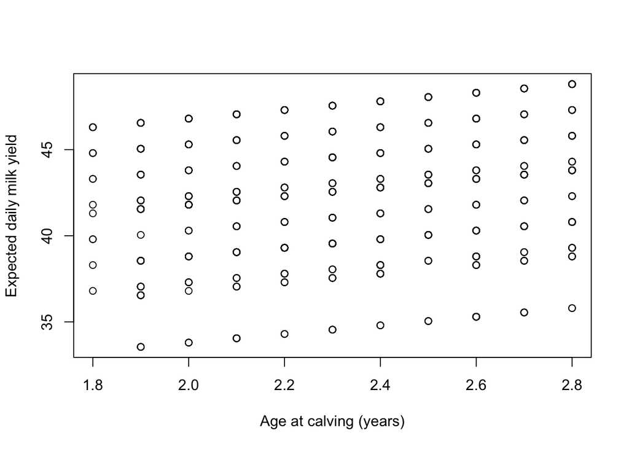

```r
plot(
  dat_dmy$age,
  dat_dmy$dmy_exp,
  xlab = "Age at calving (years)",
  ylab = "Expected daily milk yield"
)
```

# 12. Visualizing farm differences

A boxplot provides a simple visualization of differences among farms.

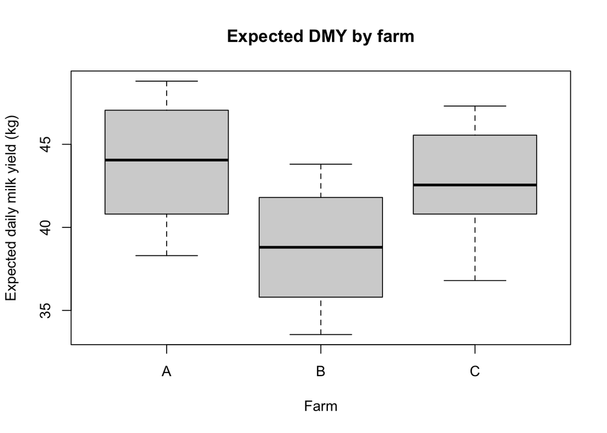

```r
boxplot(
  dmy_exp ~ farm,
  data = dat_dmy,
  xlab = "Farm",
  ylab = "Expected daily milk yield (kg)",
  main = "Expected DMY by farm"
)
```

## Think about it

We know that Farm A received a larger simulated effect than Farm B.

However, the difference between the **raw farm means** does not necessarily have to equal exactly the farm effect.

Why?

Because the distribution of:

- age;
- season of calving

may differ among farms.

This distinction will become particularly important when we fit a statistical model.

# 13. Can a linear model recover the effects used in the simulation?

This is one of the main advantages of simulation.

Because **we generated the data ourselves**, we know the true parameter values.

For example:

```r
farm_effect
```

```
##   A   B   C
## 5.0 0.0 3.5
```

```r
calvSeason_effect
```

```
## winter spring summer   fall
##      0      2     -3      5
```

```r
beta_age
```

```
## [1] 2.5
```

Now imagine that `dmy_exp` came from a real dataset and that we did not know these values.

Could we estimate them?

We fit a linear model:

```r
mod <- lm(
  dmy_exp ~ farm + calv_season + age,
  data = dat_dmy
)
```

Inspect the results:

```r
summary(mod)
```

```
##
## Call:
## lm(formula = dmy_exp ~ farm + calv_season + age, data = dat_dmy)
##
## Residuals:
##        Min         1Q     Median         3Q        Max
## -1.974e-14 -5.610e-15 -4.000e-15 -1.600e-15  1.319e-12
##
## Coefficients:
##                     Estimate Std. Error    t value Pr(>|t|)
## (Intercept)        4.180e+01  1.596e-14  2.619e+15   <2e-16 ***
## farmB             -5.000e+00  4.896e-15 -1.021e+15   <2e-16 ***
## farmC             -1.500e+00  4.398e-15 -3.411e+14   <2e-16 ***
## calv_seasonspring -3.000e+00  5.134e-15 -5.843e+14   <2e-16 ***
## calv_seasonsummer -8.000e+00  5.087e-15 -1.573e+15   <2e-16 ***
## calv_seasonwinter -5.000e+00  5.341e-15 -9.362e+14   <2e-16 ***
## age                2.500e+00  6.572e-15  3.804e+14   <2e-16 ***
## ---
## Signif. codes:  0 '***' 0.001 '**' 0.01 '*' 0.05 '.' 0.1 ' ' 1
##
## Residual standard error: 5.962e-14 on 993 degrees of freedom
## Multiple R-squared:      1,  Adjusted R-squared:      1
## F-statistic: 6.386e+29 on 6 and 993 DF,  p-value: < 2.2e-16
```

# 14. Interpreting the linear model

The fitted model can be represented as:

$$y = X\beta + e$$

where:

- $y$ = observed phenotype;
- $X$ = design matrix;
- $\beta$ = systematic effects;
- $e$ = residual.

For our example:

$$DMY_i =
\mu +
Farm_i +
Season_i +
\beta_{age}Age_i$$

R estimates the coefficients associated with these effects.

Because we generated the data, we can compare:

**True values**

versus

**Estimated values**

```r
coef(mod)
```

```
##       (Intercept)             farmB             farmC calv_seasonspring
##              41.8              -5.0              -1.5              -3.0
## calv_seasonsummer calv_seasonwinter               age
##              -8.0              -5.0               2.5
```

# 15. An important point about reference levels

For categorical variables, R uses one category as a **reference level**.

Check:

```r
levels(factor(dat_dmy$farm))
```

```
## [1] "A" "B" "C"
```

```r
levels(factor(dat_dmy$calv_season))
```

```
## [1] "fall"   "spring" "summer" "winter"
```

The coefficients shown by `lm()` represent differences relative to the reference category.

For example, if Farm A is the reference, R does not directly report:

```
Farm A = 5
Farm B = 0
Farm C = 3.5
```

Instead, the estimated coefficients represent contrasts such as:

$$Farm_B - Farm_A$$

and

$$Farm_C - Farm_A$$

Therefore, understanding the reference category is essential when interpreting a linear model.

# Activities

## Activity 1 — Build your own phenotypic population

Choose a quantitative trait of interest in animal production.

Examples include:

- body weight;
- milk yield;
- average daily gain;
- feed intake;
- carcass weight.

Find or define biologically reasonable values for the **population mean** and **standard deviation**.

### Tasks

1. Simulate phenotypes for **500 animals**.
2. Calculate the mean and standard deviation of the simulated population.
3. Compare the simulated values with the parameters used to generate the population.
4. Plot the distribution of the phenotype.
5. Repeat the simulation using **5,000 animals**.

### Questions

- What happens when the number of simulated animals increases?
- Does increasing the sample size change the biological variability of the population?

## Activity 2 — Explore phenotypic variability

Use the same trait and population mean from Activity 1.

Create three populations with the same mean but different levels of variability:

- **Low variability:** SD = 50% of the original SD
- **Original variability:** SD = the original SD
- **High variability:** SD = 200% of the original SD

Use the same number of animals in all three populations.

### Tasks

1. Simulate the three populations.
2. Calculate the mean and SD of each population.
3. Plot their distributions.
4. Compare the range of phenotypic values among populations.

### Questions

- Did changing the SD modify the expected population mean?
- Which population shows the greatest differences among animals?
- What biological situations could produce greater phenotypic variability?

## Activity 3 — Create a farm effect

Return to the original population from Activity 1.

Create **three farms** and randomly assign each animal to one farm.

The farms do not need to contain the same number of animals.

Define a different effect on the phenotype for each farm.

### Tasks

1. Define the probability that an animal belongs to each farm.
2. Define a biologically reasonable effect for Farms A, B, and C.
3. Assign the corresponding farm effect to each animal.
4. Calculate the expected phenotype including the farm effect.
5. Calculate the average expected phenotype for each farm.
6. Create a boxplot comparing the three farms.

### Questions

- Which farm has the highest expected phenotype?
- Does the difference between farms correspond to the effects that you defined?
- Why might farms have different phenotypic means in a real animal population?
- Is the farm effect genetic or environmental in this simulation?

## Activity 4 — Build a complete systematic-effects model

Expand the population from Activity 3 by including two additional systematic effects:

- **season** as a categorical variable;
- **age** as a continuous variable.

Define the magnitude of each effect yourself.

Your expected phenotype should follow the general model:

$$y_i =
\mu +
Farm_i +
Season_i +
\beta_{age}Age_i$$

### Tasks

1. Simulate a season for each animal.
2. Define an effect for each season.
3. Simulate a biologically reasonable range of ages.
4. Define the regression coefficient for age.
5. Calculate the expected phenotype for every animal.
6. Explore the expected phenotype using descriptive statistics and graphical representations.

### Questions

- Which effect produces the largest differences in your simulated population?
- Can two animals have the same population mean but different expected phenotypes? Why?

## Activity 5 — Can the statistical model recover the truth?

Use the dataset created in Activity 4.

Remember that because **you simulated the data**, you know the true values of:

- farm effects;
- season effects;
- age coefficient.

Now analyze the simulated data as if it were a real dataset.

Fit the following linear model:

$$y_i =
\mu +
Farm_i +
Season_i +
\beta_{age}Age_i +
e_i$$

### Tasks

1. Fit a linear model including farm, season, and age.
2. Identify the reference categories used by R.
3. Extract the estimated model coefficients.
4. Compare the estimated coefficients with the values used to simulate the data.

### Questions

- Did the model recover the values used to generate the data?
- Why are categorical effects expressed relative to a reference category?
- What is the advantage of using simulated data when learning statistical models?

### Final discussion

In a real dataset, the true effects are unknown.

In a simulation:

**WE DEFINE THE TRUTH → GENERATE DATA → FIT THE MODEL → COMPARE THE ESTIMATES WITH THE TRUTH**